# Tópico 3 - Manipulação de dados com dplyr

Document Author

2022-05-14

Vamos começar carregando os pacotes que vamos utilizar neste script.

```r
library(tidyverse)
```

Então podemos importar a base de dados que vamos utilizar:

```r
dados_pnud <- read_csv2("dados/base_pnud_min.csv")
```

Quais são as informações disponíveis na base?

```r
dicionario_pnud <- read_csv2("dados/dicionario_base_pnud_min.csv")
```

Podemos ver a estrutura da base de dados usando a função `glimpse()`:

```r
glimpse(dados_pnud)
```

```
## Rows: 16,686
## Columns: 15
## $ ano       <dbl> 1991, 1991, 1991, 1991, 1991, 1991, 1991, 1991, 1991, 1991, …
## $ muni_id   <dbl> 1100015, 1100023, 1100031, 1100049, 1100056, 1100064, 110007…
## $ muni_nm   <chr> "ALTA FLORESTA D'OESTE", "ARIQUEMES", "CABIXI", "CACOAL", "C…
## $ uf_sigla  <chr> "RO", "RO", "RO", "RO", "RO", "RO", "RO", "RO", "RO", "RO", …
## $ regiao_nm <chr> "Norte", "Norte", "Norte", "Norte", "Norte", "Norte", "Norte…
## $ idhm      <dbl> 0.329, 0.432, 0.309, 0.407, 0.386, 0.376, 0.203, 0.425, 0.38…
## $ idhm_e    <dbl> 0.112, 0.199, 0.108, 0.171, 0.167, 0.151, 0.039, 0.220, 0.15…
## $ idhm_l    <dbl> 0.617, 0.684, 0.636, 0.667, 0.629, 0.658, 0.572, 0.629, 0.65…
## $ idhm_r    <dbl> 0.516, 0.593, 0.430, 0.593, 0.547, 0.536, 0.373, 0.553, 0.56…
## $ espvida   <dbl> 62.01, 66.02, 63.16, 65.03, 62.73, 64.46, 59.32, 62.76, 64.1…
## $ rdpc      <dbl> 198.46, 319.47, 116.38, 320.24, 240.10, 224.82, 81.38, 250.0…
## $ gini      <dbl> 0.63, 0.57, 0.70, 0.66, 0.60, 0.62, 0.59, 0.65, 0.63, 0.60, …
## $ pop       <dbl> 22835, 55018, 5846, 66534, 19030, 25070, 10737, 6902, 22505,…
## $ lat       <dbl> -11.929, -9.913, -13.492, -11.438, -13.189, -13.117, -12.962…
## $ lon       <dbl> -61.996, -63.041, -60.545, -61.448, -60.812, -60.542, -60.88…
```

Podemos ver os nomes das colunas da base de dados usando a função `names()`:

```r
names(dados_pnud)
```

```
##  [1] "ano"       "muni_id"   "muni_nm"   "uf_sigla"  "regiao_nm" "idhm"
##  [7] "idhm_e"    "idhm_l"    "idhm_r"    "espvida"   "rdpc"      "gini"
## [13] "pop"       "lat"       "lon"
```

## dplyr

- `select()`: seleciona colunas da base de dados
- `filter()`: filtra linhas da base de dados
- `arrange()`: reordena as linhas da base de dados
- `mutate()`: cria novas colunas da base de dados (ou atualiza as colunas existentes)
- `group_by()` + `summarise()`: agrupa e sumariza da base de dados

## select

Podemos selecionar colunas da base de dados com a função `select()`.

Sintaxe: select(nome_da_base, regras_para_selecionar_colunas)

Selecionando uma coluna:

```r
nome_municipios <- select(dados_pnud, muni_nm)
```

Obs: Enquanto a gente não usar a atribuição `<-`, o objeto não é alterado!

Selecionando várias colunas:

```r
select(dados_pnud, muni_nm, uf_sigla)
```

```
## # A tibble: 16,686 × 2
##    muni_nm               uf_sigla
##    <chr>                 <chr>
##  1 ALTA FLORESTA D'OESTE RO
##  2 ARIQUEMES             RO
##  3 CABIXI                RO
##  4 CACOAL                RO
##  5 CEREJEIRAS            RO
##  6 COLORADO DO OESTE     RO
##  7 CORUMBIARA            RO
##  8 COSTA MARQUES         RO
##  9 ESPIGÃO D'OESTE       RO
## 10 GUAJARÁ-MIRIM         RO
## # … with 16,676 more rows
```

A função select respeita a ordem das colunas:

```r
select(dados_pnud, uf_sigla, muni_nm, pop)
```

```
## # A tibble: 16,686 × 3
##    uf_sigla muni_nm                 pop
##    <chr>    <chr>                 <dbl>
##  1 RO       ALTA FLORESTA D'OESTE 22835
##  2 RO       ARIQUEMES             55018
##  3 RO       CABIXI                 5846
##  4 RO       CACOAL                66534
##  5 RO       CEREJEIRAS            19030
##  6 RO       COLORADO DO OESTE     25070
##  7 RO       CORUMBIARA            10737
##  8 RO       COSTA MARQUES          6902
##  9 RO       ESPIGÃO D'OESTE       22505
## 10 RO       GUAJARÁ-MIRIM         31240
## # … with 16,676 more rows
```

O operador `:` pode ser usado aqui para selecionar uma sequência de colunas:

```r
select(dados_pnud, idhm:pop)
```

```
## # A tibble: 16,686 × 8
##     idhm idhm_e idhm_l idhm_r espvida  rdpc  gini   pop
##    <dbl>  <dbl>  <dbl>  <dbl>   <dbl> <dbl> <dbl> <dbl>
##  1 0.329  0.112  0.617  0.516    62.0 198.   0.63 22835
##  2 0.432  0.199  0.684  0.593    66.0 319.   0.57 55018
##  3 0.309  0.108  0.636  0.43     63.2 116.   0.7   5846
##  4 0.407  0.171  0.667  0.593    65.0 320.   0.66 66534
##  5 0.386  0.167  0.629  0.547    62.7 240.   0.6  19030
##  6 0.376  0.151  0.658  0.536    64.5 225.   0.62 25070
##  7 0.203  0.039  0.572  0.373    59.3  81.4  0.59 10737
##  8 0.425  0.22   0.629  0.553    62.8 250.   0.65  6902
##  9 0.388  0.159  0.653  0.561    64.2 263.   0.63 22505
## 10 0.468  0.247  0.662  0.625    64.7 391.   0.6  31240
## # … with 16,676 more rows
```

Podemos selecionar colunas por exclusão:

```r
select(dados_pnud, -lat, -lon)
```

```
## # A tibble: 16,686 × 13
##      ano muni_id muni_nm   uf_sigla regiao_nm  idhm idhm_e idhm_l idhm_r espvida
##    <dbl>   <dbl> <chr>     <chr>    <chr>     <dbl>  <dbl>  <dbl>  <dbl>   <dbl>
##  1  1991 1100015 ALTA FLO… RO       Norte     0.329  0.112  0.617  0.516    62.0
##  2  1991 1100023 ARIQUEMES RO       Norte     0.432  0.199  0.684  0.593    66.0
##  3  1991 1100031 CABIXI    RO       Norte     0.309  0.108  0.636  0.43     63.2
##  4  1991 1100049 CACOAL    RO       Norte     0.407  0.171  0.667  0.593    65.0
##  5  1991 1100056 CEREJEIR… RO       Norte     0.386  0.167  0.629  0.547    62.7
##  6  1991 1100064 COLORADO… RO       Norte     0.376  0.151  0.658  0.536    64.5
##  7  1991 1100072 CORUMBIA… RO       Norte     0.203  0.039  0.572  0.373    59.3
##  8  1991 1100080 COSTA MA… RO       Norte     0.425  0.22   0.629  0.553    62.8
##  9  1991 1100098 ESPIGÃO … RO       Norte     0.388  0.159  0.653  0.561    64.2
## 10  1991 1100106 GUAJARÁ-… RO       Norte     0.468  0.247  0.662  0.625    64.7
## # … with 16,676 more rows, and 3 more variables: rdpc <dbl>, gini <dbl>,
## #   pop <dbl>
```

Selecione todas as colunas que comecem com idhm:

```r
# resposta da Mariana
select(dados_pnud, idhm:idhm_r)
```

```
## # A tibble: 16,686 × 4
##     idhm idhm_e idhm_l idhm_r
##    <dbl>  <dbl>  <dbl>  <dbl>
##  1 0.329  0.112  0.617  0.516
##  2 0.432  0.199  0.684  0.593
##  3 0.309  0.108  0.636  0.43
##  4 0.407  0.171  0.667  0.593
##  5 0.386  0.167  0.629  0.547
##  6 0.376  0.151  0.658  0.536
##  7 0.203  0.039  0.572  0.373
##  8 0.425  0.22   0.629  0.553
##  9 0.388  0.159  0.653  0.561
## 10 0.468  0.247  0.662  0.625
## # … with 16,676 more rows
```

```r
# busca padrão no começo do nome da coluna
select(dados_pnud, starts_with("idhm"))
```

```
## # A tibble: 16,686 × 4
##     idhm idhm_e idhm_l idhm_r
##    <dbl>  <dbl>  <dbl>  <dbl>
##  1 0.329  0.112  0.617  0.516
##  2 0.432  0.199  0.684  0.593
##  3 0.309  0.108  0.636  0.43
##  4 0.407  0.171  0.667  0.593
##  5 0.386  0.167  0.629  0.547
##  6 0.376  0.151  0.658  0.536
##  7 0.203  0.039  0.572  0.373
##  8 0.425  0.22   0.629  0.553
##  9 0.388  0.159  0.653  0.561
## 10 0.468  0.247  0.662  0.625
## # … with 16,676 more rows
```

```r
# busca padrão em qualquer lugar no nome da coluna
select(dados_pnud, contains("idhm"))
```

```
## # A tibble: 16,686 × 4
##     idhm idhm_e idhm_l idhm_r
##    <dbl>  <dbl>  <dbl>  <dbl>
##  1 0.329  0.112  0.617  0.516
##  2 0.432  0.199  0.684  0.593
##  3 0.309  0.108  0.636  0.43
##  4 0.407  0.171  0.667  0.593
##  5 0.386  0.167  0.629  0.547
##  6 0.376  0.151  0.658  0.536
##  7 0.203  0.039  0.572  0.373
##  8 0.425  0.22   0.629  0.553
##  9 0.388  0.159  0.653  0.561
## 10 0.468  0.247  0.662  0.625
## # … with 16,676 more rows
```

```r
# busca padrao no final do nome da coluna
select(dados_pnud, ends_with("nm"))
```

```
## # A tibble: 16,686 × 2
##    muni_nm               regiao_nm
##    <chr>                 <chr>
##  1 ALTA FLORESTA D'OESTE Norte
##  2 ARIQUEMES             Norte
##  3 CABIXI                Norte
##  4 CACOAL                Norte
##  5 CEREJEIRAS            Norte
##  6 COLORADO DO OESTE     Norte
##  7 CORUMBIARA            Norte
##  8 COSTA MARQUES         Norte
##  9 ESPIGÃO D'OESTE       Norte
## 10 GUAJARÁ-MIRIM         Norte
## # … with 16,676 more rows
```

```r
select(dados_pnud, ends_with("nm")) %>%
  head() %>%  # pega só as primeiras 6 linhas
  knitr::kable() # funcao para criar tabela
```

| muni_nm | regiao_nm |
| --- | --- |
| ALTA FLORESTA D’OESTE | Norte |
| ARIQUEMES | Norte |
| CABIXI | Norte |
| CACOAL | Norte |
| CEREJEIRAS | Norte |
| COLORADO DO OESTE | Norte |

## arrange

Podemos ordenar a base de dados com a função `arrange()`.

Sintaxe: arrange(nome_da_base, coluna_para_usar_para_ordenar)

O padrão de ordenação é crescente:

```r
arrange(dados_pnud, pop)
```

```
## # A tibble: 16,686 × 15
##      ano muni_id muni_nm   uf_sigla regiao_nm  idhm idhm_e idhm_l idhm_r espvida
##    <dbl>   <dbl> <chr>     <chr>    <chr>     <dbl>  <dbl>  <dbl>  <dbl>   <dbl>
##  1  1991 5107743 SANTA CR… MT       Centro-O… 0.397  0.138  0.708  0.642    67.5
##  2  1991 5108303 UNIÃO DO… MT       Centro-O… 0.309  0.06   0.698  0.705    66.8
##  3  1991 1100452 BURITIS   RO       Norte     0.325  0.113  0.638  0.474    63.3
##  4  1991 5107875 SAPEZAL   MT       Centro-O… 0.341  0.077  0.78   0.663    71.8
##  5  1991 1720150 SÃO FÉLI… TO       Norte     0.294  0.137  0.512  0.362    55.7
##  6  1991 5102686 CAMPOS D… MT       Centro-O… 0.46   0.226  0.713  0.604    67.8
##  7  1991 3507209 BORÁ      SP       Sudeste   0.506  0.307  0.76   0.555    70.6
##  8  1991 5212253 LAGOA SA… GO       Centro-O… 0.382  0.141  0.718  0.551    68.1
##  9  2000 5212253 LAGOA SA… GO       Centro-O… 0.559  0.366  0.815  0.585    73.9
## 10  2000 3507209 BORÁ      SP       Sudeste   0.649  0.527  0.794  0.652    72.6
## # … with 16,676 more rows, and 5 more variables: rdpc <dbl>, gini <dbl>,
## #   pop <dbl>, lat <dbl>, lon <dbl>
```

Para ordenar de forma decrescente, podemos usar a função `desc()`:

```r
arrange(dados_pnud, desc(pop))
```

```
## # A tibble: 16,686 × 15
##      ano muni_id muni_nm   uf_sigla regiao_nm  idhm idhm_e idhm_l idhm_r espvida
##    <dbl>   <dbl> <chr>     <chr>    <chr>     <dbl>  <dbl>  <dbl>  <dbl>   <dbl>
##  1  2010 3550308 SÃO PAULO SP       Sudeste   0.805  0.725  0.855  0.843    76.3
##  2  2000 3550308 SÃO PAULO SP       Sudeste   0.733  0.614  0.796  0.807    72.8
##  3  1991 3550308 SÃO PAULO SP       Sudeste   0.626  0.421  0.742  0.784    69.5
##  4  2010 3304557 RIO DE J… RJ       Sudeste   0.799  0.719  0.845  0.84     75.7
##  5  2000 3304557 RIO DE J… RJ       Sudeste   0.716  0.607  0.754  0.803    70.3
##  6  1991 3304557 RIO DE J… RJ       Sudeste   0.639  0.483  0.714  0.757    67.8
##  7  2010 2927408 SALVADOR  BA       Nordeste  0.759  0.679  0.835  0.772    75.1
##  8  2010 5300108 BRASÍLIA  DF       Centro-O… 0.824  0.742  0.873  0.863    77.4
##  9  2010 2304400 FORTALEZA CE       Nordeste  0.754  0.695  0.824  0.749    74.4
## 10  2000 2927408 SALVADOR  BA       Nordeste  0.654  0.525  0.744  0.715    69.6
## # … with 16,676 more rows, and 5 more variables: rdpc <dbl>, gini <dbl>,
## #   pop <dbl>, lat <dbl>, lon <dbl>
```

Podemos ordenar de acordo com os valores de duas colunas:

```r
arrange(dados_pnud, ano, desc(pop))
```

```
## # A tibble: 16,686 × 15
##      ano muni_id muni_nm   uf_sigla regiao_nm  idhm idhm_e idhm_l idhm_r espvida
##    <dbl>   <dbl> <chr>     <chr>    <chr>     <dbl>  <dbl>  <dbl>  <dbl>   <dbl>
##  1  1991 3550308 SÃO PAULO SP       Sudeste   0.626  0.421  0.742  0.784    69.5
##  2  1991 3304557 RIO DE J… RJ       Sudeste   0.639  0.483  0.714  0.757    67.8
##  3  1991 2927408 SALVADOR  BA       Nordeste  0.563  0.383  0.679  0.686    65.7
##  4  1991 3106200 Belo Hor… MG       Sudeste   0.602  0.406  0.727  0.74     68.6
##  5  1991 2304400 FORTALEZA CE       Nordeste  0.546  0.367  0.683  0.65     66.0
##  6  1991 5300108 BRASÍLIA  DF       Centro-O… 0.616  0.419  0.731  0.762    68.9
##  7  1991 4106902 CURITIBA  PR       Sul       0.64   0.476  0.728  0.755    68.7
##  8  1991 2611606 RECIFE    PE       Nordeste  0.576  0.409  0.676  0.692    65.6
##  9  1991 4314902 PORTO AL… RS       Sul       0.66   0.494  0.748  0.779    69.9
## 10  1991 1501402 BELÉM     PA       Norte     0.562  0.371  0.71   0.674    67.6
## # … with 16,676 more rows, and 5 more variables: rdpc <dbl>, gini <dbl>,
## #   pop <dbl>, lat <dbl>, lon <dbl>
```

A ordenação de textos segue a ordem alfabética:

```r
arrange(dados_pnud, muni_nm)
```

```
## # A tibble: 16,686 × 15
##      ano muni_id muni_nm   uf_sigla regiao_nm  idhm idhm_e idhm_l idhm_r espvida
##    <dbl>   <dbl> <chr>     <chr>    <chr>     <dbl>  <dbl>  <dbl>  <dbl>   <dbl>
##  1  1991 5200050 ABADIA D… GO       Centro-O… 0.408  0.183  0.658  0.563    64.5
##  2  2000 5200050 ABADIA D… GO       Centro-O… 0.569  0.386  0.765  0.623    70.9
##  3  2010 5200050 ABADIA D… GO       Centro-O… 0.708  0.622  0.83   0.687    74.8
##  4  1991 3100104 Abadia d… MG       Sudeste   0.449  0.225  0.728  0.551    68.7
##  5  2000 3100104 Abadia d… MG       Sudeste   0.575  0.387  0.799  0.616    72.9
##  6  2010 3100104 Abadia d… MG       Sudeste   0.689  0.563  0.839  0.693    75.4
##  7  1991 5200100 ABADIÂNIA GO       Centro-O… 0.41   0.188  0.656  0.56     64.4
##  8  2000 5200100 ABADIÂNIA GO       Centro-O… 0.503  0.292  0.73   0.598    68.8
##  9  2010 5200100 ABADIÂNIA GO       Centro-O… 0.689  0.579  0.841  0.671    75.5
## 10  1991 3100203 Abaeté    MG       Sudeste   0.417  0.18   0.717  0.561    68.0
## # … with 16,676 more rows, and 5 more variables: rdpc <dbl>, gini <dbl>,
## #   pop <dbl>, lat <dbl>, lon <dbl>
```

- Exercício: colunas: ano, uf, nome do municipio, gini ordenacao: ano descente (2010, 2000, 1991) e gini crescente (os muni com menores inidices primeiro)

```r
# jeito 1
tabela_pnud <- select(dados_pnud, ano, uf_sigla, muni_nm, gini)
arrange(tabela_pnud, desc(ano), gini)
```

```
## # A tibble: 16,686 × 4
##      ano uf_sigla muni_nm                gini
##    <dbl> <chr>    <chr>                 <dbl>
##  1  2010 SC       BOTUVERÁ               0.28
##  2  2010 RS       SÃO JOSÉ DO HORTÊNCIO  0.28
##  3  2010 RS       ALTO FELIZ             0.29
##  4  2010 RS       SÃO VENDELINO          0.29
##  5  2010 RS       VALE REAL              0.29
##  6  2010 RS       SANTA MARIA DO HERVAL  0.3
##  7  2010 RS       CAMPESTRE DA SERRA     0.31
##  8  2010 RS       TUPANDI                0.31
##  9  2010 MG       Córrego Fundo          0.32
## 10  2010 SC       SANTA ROSA DE LIMA     0.32
## # … with 16,676 more rows
```

```r
# jeito 2
arrange(select(dados_pnud, ano, uf_sigla, muni_nm, gini),
        desc(ano), gini)
```

```
## # A tibble: 16,686 × 4
##      ano uf_sigla muni_nm                gini
##    <dbl> <chr>    <chr>                 <dbl>
##  1  2010 SC       BOTUVERÁ               0.28
##  2  2010 RS       SÃO JOSÉ DO HORTÊNCIO  0.28
##  3  2010 RS       ALTO FELIZ             0.29
##  4  2010 RS       SÃO VENDELINO          0.29
##  5  2010 RS       VALE REAL              0.29
##  6  2010 RS       SANTA MARIA DO HERVAL  0.3
##  7  2010 RS       CAMPESTRE DA SERRA     0.31
##  8  2010 RS       TUPANDI                0.31
##  9  2010 MG       Córrego Fundo          0.32
## 10  2010 SC       SANTA ROSA DE LIMA     0.32
## # … with 16,676 more rows
```

## pipe

É comum fazer mais de uma operação em sequência. Por exemplo: selecionar colunas, e depois ordenar!

Objetivo: gerar uma base que tem as colunas referentes ao ano, sigla da UF, nome do município e gini. Essa base deve estar ordenada por ano e gini.

```r
# jeito 1
tabela_pnud <- select(dados_pnud, ano, uf_sigla, muni_nm, gini)
arrange(tabela_pnud, desc(ano), gini)
```

```
## # A tibble: 16,686 × 4
##      ano uf_sigla muni_nm                gini
##    <dbl> <chr>    <chr>                 <dbl>
##  1  2010 SC       BOTUVERÁ               0.28
##  2  2010 RS       SÃO JOSÉ DO HORTÊNCIO  0.28
##  3  2010 RS       ALTO FELIZ             0.29
##  4  2010 RS       SÃO VENDELINO          0.29
##  5  2010 RS       VALE REAL              0.29
##  6  2010 RS       SANTA MARIA DO HERVAL  0.3
##  7  2010 RS       CAMPESTRE DA SERRA     0.31
##  8  2010 RS       TUPANDI                0.31
##  9  2010 MG       Córrego Fundo          0.32
## 10  2010 SC       SANTA ROSA DE LIMA     0.32
## # … with 16,676 more rows
```

```r
# jeito 2
arrange(select(dados_pnud, ano, uf_sigla, muni_nm, gini),
        desc(ano), gini)
```

```
## # A tibble: 16,686 × 4
##      ano uf_sigla muni_nm                gini
##    <dbl> <chr>    <chr>                 <dbl>
##  1  2010 SC       BOTUVERÁ               0.28
##  2  2010 RS       SÃO JOSÉ DO HORTÊNCIO  0.28
##  3  2010 RS       ALTO FELIZ             0.29
##  4  2010 RS       SÃO VENDELINO          0.29
##  5  2010 RS       VALE REAL              0.29
##  6  2010 RS       SANTA MARIA DO HERVAL  0.3
##  7  2010 RS       CAMPESTRE DA SERRA     0.31
##  8  2010 RS       TUPANDI                0.31
##  9  2010 MG       Córrego Fundo          0.32
## 10  2010 SC       SANTA ROSA DE LIMA     0.32
## # … with 16,676 more rows
```

Podemos reescrever esse código com o pipe. O pipe conecta as operações, passando o resultado da última operação como primeiro argumento das próximas etapas.

- `|>` é o pipe do base R, funciona a partir da versão 4.1 do R.
- `%>%` é a versão do tidyverse. Precisa rodar `library(tidyverse)` ou `library(magrittr)` antes.
- Atalho: CTRL + SHIFT + M

```r
# library(tidyverse)
# library(magrittr)
```

```r
select(dados_pnud, ano, uf_sigla, muni_nm, gini) %>%
arrange(desc(ano), gini)
```

```
## # A tibble: 16,686 × 4
##      ano uf_sigla muni_nm                gini
##    <dbl> <chr>    <chr>                 <dbl>
##  1  2010 SC       BOTUVERÁ               0.28
##  2  2010 RS       SÃO JOSÉ DO HORTÊNCIO  0.28
##  3  2010 RS       ALTO FELIZ             0.29
##  4  2010 RS       SÃO VENDELINO          0.29
##  5  2010 RS       VALE REAL              0.29
##  6  2010 RS       SANTA MARIA DO HERVAL  0.3
##  7  2010 RS       CAMPESTRE DA SERRA     0.31
##  8  2010 RS       TUPANDI                0.31
##  9  2010 MG       Córrego Fundo          0.32
## 10  2010 SC       SANTA ROSA DE LIMA     0.32
## # … with 16,676 more rows
```

```r
dados_pnud %>%
  select(ano, uf_sigla, muni_nm, gini) %>%
  arrange(desc(ano), gini)
```

```
## # A tibble: 16,686 × 4
##      ano uf_sigla muni_nm                gini
##    <dbl> <chr>    <chr>                 <dbl>
##  1  2010 SC       BOTUVERÁ               0.28
##  2  2010 RS       SÃO JOSÉ DO HORTÊNCIO  0.28
##  3  2010 RS       ALTO FELIZ             0.29
##  4  2010 RS       SÃO VENDELINO          0.29
##  5  2010 RS       VALE REAL              0.29
##  6  2010 RS       SANTA MARIA DO HERVAL  0.3
##  7  2010 RS       CAMPESTRE DA SERRA     0.31
##  8  2010 RS       TUPANDI                0.31
##  9  2010 MG       Córrego Fundo          0.32
## 10  2010 SC       SANTA ROSA DE LIMA     0.32
## # … with 16,676 more rows
```

## Pausa nos verbos: distinct

Quais são os valores únicos/distintos em uma coluna?

- A base dados_pnud possui informações referentes à quais anos?

```r
unique(dados_pnud$uf_sigla)
```

```
##  [1] "RO" "AC" "AM" "RR" "PA" "AP" "TO" "MA" "PI" "CE" "RN" "PB" "PE" "AL" "SE"
## [16] "BA" "MG" "ES" "RJ" "SP" "PR" "SC" "RS" "MS" "MT" "GO" "DF"
```

```r
dados_pnud |>
  distinct(ano)
```

```
## # A tibble: 3 × 1
##     ano
##   <dbl>
## 1  1991
## 2  2000
## 3  2010
```

```r
dados_pnud |>
  distinct(ano, regiao_nm)
```

```
## # A tibble: 15 × 2
##      ano regiao_nm
##    <dbl> <chr>
##  1  1991 Norte
##  2  1991 Nordeste
##  3  1991 Sudeste
##  4  1991 Sul
##  5  1991 Centro-Oeste
##  6  2000 Norte
##  7  2000 Nordeste
##  8  2000 Sudeste
##  9  2000 Sul
## 10  2000 Centro-Oeste
## 11  2010 Norte
## 12  2010 Nordeste
## 13  2010 Sudeste
## 14  2010 Sul
## 15  2010 Centro-Oeste
```

- A base dados_pnud possui informações referentes à quais UFs?

```r
dados_pnud |>
  distinct(uf_sigla) |>
  arrange(uf_sigla)
```

```
## # A tibble: 27 × 1
##    uf_sigla
##    <chr>
##  1 AC
##  2 AL
##  3 AM
##  4 AP
##  5 BA
##  6 CE
##  7 DF
##  8 ES
##  9 GO
## 10 MA
## # … with 17 more rows
```

## mutate

- Podemos modificar colunas e criar novas colunas usando a função `mutate()`.
- Exemplo: vamos modificar a coluna pop para que ela armazene a população em milhares.

mutate(nome_da_coluna_que_queremos_criar = operacao_que_queremos_fazer)

```r
# - Exemplo: vamos criar uma nova coluna chamada `pop_milhares` para que ela armazene a população em milhares.

dados_pnud |>
  mutate(pop_milhares = pop/1000)
```

```
## # A tibble: 16,686 × 16
##      ano muni_id muni_nm   uf_sigla regiao_nm  idhm idhm_e idhm_l idhm_r espvida
##    <dbl>   <dbl> <chr>     <chr>    <chr>     <dbl>  <dbl>  <dbl>  <dbl>   <dbl>
##  1  1991 1100015 ALTA FLO… RO       Norte     0.329  0.112  0.617  0.516    62.0
##  2  1991 1100023 ARIQUEMES RO       Norte     0.432  0.199  0.684  0.593    66.0
##  3  1991 1100031 CABIXI    RO       Norte     0.309  0.108  0.636  0.43     63.2
##  4  1991 1100049 CACOAL    RO       Norte     0.407  0.171  0.667  0.593    65.0
##  5  1991 1100056 CEREJEIR… RO       Norte     0.386  0.167  0.629  0.547    62.7
##  6  1991 1100064 COLORADO… RO       Norte     0.376  0.151  0.658  0.536    64.5
##  7  1991 1100072 CORUMBIA… RO       Norte     0.203  0.039  0.572  0.373    59.3
##  8  1991 1100080 COSTA MA… RO       Norte     0.425  0.22   0.629  0.553    62.8
##  9  1991 1100098 ESPIGÃO … RO       Norte     0.388  0.159  0.653  0.561    64.2
## 10  1991 1100106 GUAJARÁ-… RO       Norte     0.468  0.247  0.662  0.625    64.7
## # … with 16,676 more rows, and 6 more variables: rdpc <dbl>, gini <dbl>,
## #   pop <dbl>, lat <dbl>, lon <dbl>, pop_milhares <dbl>
```

```r
# - Como arredondar? Função `round()`. Vamos experimentar arredondar a coluna de esperança de vida para ter apenas 1 casa decimal.
dados_pnud |>
  mutate(pop_milhares = pop/1000,
         pop_milhares = round(pop_milhares, 1))
```

```
## # A tibble: 16,686 × 16
##      ano muni_id muni_nm   uf_sigla regiao_nm  idhm idhm_e idhm_l idhm_r espvida
##    <dbl>   <dbl> <chr>     <chr>    <chr>     <dbl>  <dbl>  <dbl>  <dbl>   <dbl>
##  1  1991 1100015 ALTA FLO… RO       Norte     0.329  0.112  0.617  0.516    62.0
##  2  1991 1100023 ARIQUEMES RO       Norte     0.432  0.199  0.684  0.593    66.0
##  3  1991 1100031 CABIXI    RO       Norte     0.309  0.108  0.636  0.43     63.2
##  4  1991 1100049 CACOAL    RO       Norte     0.407  0.171  0.667  0.593    65.0
##  5  1991 1100056 CEREJEIR… RO       Norte     0.386  0.167  0.629  0.547    62.7
##  6  1991 1100064 COLORADO… RO       Norte     0.376  0.151  0.658  0.536    64.5
##  7  1991 1100072 CORUMBIA… RO       Norte     0.203  0.039  0.572  0.373    59.3
##  8  1991 1100080 COSTA MA… RO       Norte     0.425  0.22   0.629  0.553    62.8
##  9  1991 1100098 ESPIGÃO … RO       Norte     0.388  0.159  0.653  0.561    64.2
## 10  1991 1100106 GUAJARÁ-… RO       Norte     0.468  0.247  0.662  0.625    64.7
## # … with 16,676 more rows, and 6 more variables: rdpc <dbl>, gini <dbl>,
## #   pop <dbl>, lat <dbl>, lon <dbl>, pop_milhares <dbl>
```

```r
# exemplos de manipulação de textos
dados_pnud |>
  mutate(muni_id = as.character(muni_id),
         muni_nm = str_to_lower(muni_nm),
         muni_nm = abjutils::rm_accent(muni_nm))
```

```
## # A tibble: 16,686 × 15
##      ano muni_id muni_nm   uf_sigla regiao_nm  idhm idhm_e idhm_l idhm_r espvida
##    <dbl> <chr>   <chr>     <chr>    <chr>     <dbl>  <dbl>  <dbl>  <dbl>   <dbl>
##  1  1991 1100015 alta flo… RO       Norte     0.329  0.112  0.617  0.516    62.0
##  2  1991 1100023 ariquemes RO       Norte     0.432  0.199  0.684  0.593    66.0
##  3  1991 1100031 cabixi    RO       Norte     0.309  0.108  0.636  0.43     63.2
##  4  1991 1100049 cacoal    RO       Norte     0.407  0.171  0.667  0.593    65.0
##  5  1991 1100056 cerejeir… RO       Norte     0.386  0.167  0.629  0.547    62.7
##  6  1991 1100064 colorado… RO       Norte     0.376  0.151  0.658  0.536    64.5
##  7  1991 1100072 corumbia… RO       Norte     0.203  0.039  0.572  0.373    59.3
##  8  1991 1100080 costa ma… RO       Norte     0.425  0.22   0.629  0.553    62.8
##  9  1991 1100098 espigao … RO       Norte     0.388  0.159  0.653  0.561    64.2
## 10  1991 1100106 guajara-… RO       Norte     0.468  0.247  0.662  0.625    64.7
## # … with 16,676 more rows, and 5 more variables: rdpc <dbl>, gini <dbl>,
## #   pop <dbl>, lat <dbl>, lon <dbl>
```

Criar faixas de esperança de vida!

```r
dados_classificados_por_espvida <- dados_pnud |>
  mutate(classe_espvida = case_when(
    # comparacao verdadeira ~ valor que eu quero guardar!,
    # 50 até 60
    espvida >= 50 & espvida < 60 ~ "50 - 59 anos",
    # 60 até 70
    espvida >= 60 & espvida < 70 ~ "60 - 69 anos",
    # 70 até 80
    espvida >= 70 & espvida < 80 ~ "70 - 79 anos",
    # TUDO O QUE NAO FOI CLASSIFICADO!!
    TRUE ~ "Fora das faixas classificadas"
  ))
```

- [fatores](https://forcats.tidyverse.org/articles/forcats.html) são úteis em variáveis categóricas, ex: nao foi alfabetizado ensino fundamental ensino médio graduacao especializao mestrado doutorado

## count

- A função count é uma função útil para contar elementos por grupo.

```r
dados_count_espvida <- dados_classificados_por_espvida |>
  count(ano, classe_espvida)
```

## um exemplo de gráfico

```r
grafico_exemplo <- ggplot(dados_count_espvida) +
  aes(x = classe_espvida, y = n) +
  geom_col(fill = "#2E4469") +
  labs(
    x = "Faixa de esperança de vida",
    y = "Quantidade de municípios",
    caption = "Fonte: dados do pacote ....."
  ) +
  theme_minimal() +
  facet_wrap(vars(ano))

ggsave("grafico_espvida.png", grafico_exemplo, dpi = 600,
       width = 10, height = 5)
```

https://patchwork.data-imaginist.com/articles/patchwork.html

## summarise

- Podemos criar resumos da base com a função `summarise()`
- Resumindo a base: qual é a média da esperança de vida?

```r
dados_pnud |>
summarise(media_espvida = mean(espvida))
```

```
## # A tibble: 1 × 1
##   media_espvida
##           <dbl>
## 1          68.4
```

Isso não ajuda tanto pois obtemos uma informação para a base completa… e como sabemos a média por ano?

## group_by

- Podemos agrupar os dados com `group_by`.
- Agrupando por ano:

```r
dados_pnud |>
  group_by(ano)
```

```
## # A tibble: 16,686 × 15
## # Groups:   ano [3]
##      ano muni_id muni_nm   uf_sigla regiao_nm  idhm idhm_e idhm_l idhm_r espvida
##    <dbl>   <dbl> <chr>     <chr>    <chr>     <dbl>  <dbl>  <dbl>  <dbl>   <dbl>
##  1  1991 1100015 ALTA FLO… RO       Norte     0.329  0.112  0.617  0.516    62.0
##  2  1991 1100023 ARIQUEMES RO       Norte     0.432  0.199  0.684  0.593    66.0
##  3  1991 1100031 CABIXI    RO       Norte     0.309  0.108  0.636  0.43     63.2
##  4  1991 1100049 CACOAL    RO       Norte     0.407  0.171  0.667  0.593    65.0
##  5  1991 1100056 CEREJEIR… RO       Norte     0.386  0.167  0.629  0.547    62.7
##  6  1991 1100064 COLORADO… RO       Norte     0.376  0.151  0.658  0.536    64.5
##  7  1991 1100072 CORUMBIA… RO       Norte     0.203  0.039  0.572  0.373    59.3
##  8  1991 1100080 COSTA MA… RO       Norte     0.425  0.22   0.629  0.553    62.8
##  9  1991 1100098 ESPIGÃO … RO       Norte     0.388  0.159  0.653  0.561    64.2
## 10  1991 1100106 GUAJARÁ-… RO       Norte     0.468  0.247  0.662  0.625    64.7
## # … with 16,676 more rows, and 5 more variables: rdpc <dbl>, gini <dbl>,
## #   pop <dbl>, lat <dbl>, lon <dbl>
```

## group_by + summarise

- Resumindo a base: qual é a média da esperança de vida por ano?

```r
dados_pnud |>
  group_by(ano) |>
  summarise(media_espvida = mean(espvida))
```

```
## # A tibble: 3 × 2
##     ano media_espvida
##   <dbl>         <dbl>
## 1  1991          63.7
## 2  2000          68.4
## 3  2010          73.1
```

```r
dados_pnud |>
  group_by(ano, regiao_nm) |>
  summarise(media_espvida = mean(espvida))
```

[output not shown]

```
## # A tibble: 15 × 3
## # Groups:   ano [3]
##      ano regiao_nm    media_espvida
##    <dbl> <chr>                <dbl>
##  1  1991 Centro-Oeste          65.1
##  2  1991 Nordeste              58.5
##  3  1991 Norte                 61.6
##  4  1991 Sudeste               66.6
##  5  1991 Sul                   67.9
##  6  2000 Centro-Oeste          70.0
##  7  2000 Nordeste              64.2
##  8  2000 Norte                 66.4
##  9  2000 Sudeste               70.8
## 10  2000 Sul                   71.6
## 11  2010 Centro-Oeste          74.3
## 12  2010 Nordeste              70.3
## 13  2010 Norte                 71.8
## 14  2010 Sudeste               74.7
## 15  2010 Sul                   75.1
```

- Várias sumarizações:

```r
base_resumo_espvida <- dados_pnud |>
  group_by(ano) |>
  summarise(
    # media
    media_espvida = mean(espvida),
    # mediana
    mediana_espvida = median(espvida),
    # variancia
    var_espvida = var(espvida),
    # dp
    desviopadrao_espvida = sd(espvida),
    # min
    min_espvida = min(espvida),
    # max
    max_espvida = max(espvida),

    # qnt muni
    quant_muni = n()
  )

base_resumo_espvida |>
  write_csv2("base_resumo_espvida.csv")
```

- Pergunta do Rafael https://cran.r-project.org/web/packages/janitor/vignettes/tabyls.html

```r
# Com janitor
library(janitor)
dados_classificados_por_espvida |>
  tabyl(ano, classe_espvida) |>
  adorn_percentages("row") %>%
  adorn_pct_formatting(digits = 2) %>%
  adorn_ns()
```

```
##   ano  50 - 59 anos  60 - 69 anos  70 - 79 anos
##  1991 24.04% (1337) 69.20% (3849)  6.76%  (376)
##  2000  1.35%   (75) 57.82% (3216) 40.83% (2271)
##  2010  0.00%    (0) 14.44%  (803) 85.56% (4759)
```

```r
# com dplyr

dados_classificados_por_espvida |>
  group_by(ano, classe_espvida) |>
  count() |>
  ungroup() |>
  group_by(ano) |>
  mutate(porc = n / sum(n),
         porc = round(porc, 4),
         porc_com_simbolo = scales::percent(porc, accuracy = 0.01))
```

```
## # A tibble: 8 × 5
## # Groups:   ano [3]
##     ano classe_espvida     n   porc porc_com_simbolo
##   <dbl> <chr>          <int>  <dbl> <chr>
## 1  1991 50 - 59 anos    1337 0.240  24.04%
## 2  1991 60 - 69 anos    3849 0.692  69.20%
## 3  1991 70 - 79 anos     376 0.0676 6.76%
## 4  2000 50 - 59 anos      75 0.0135 1.35%
## 5  2000 60 - 69 anos    3216 0.578  57.82%
## 6  2000 70 - 79 anos    2271 0.408  40.83%
## 7  2010 60 - 69 anos     803 0.144  14.44%
## 8  2010 70 - 79 anos    4759 0.856  85.56%
```

## filter

- Para entender filtros, precisamos conhecer alguns conceitos de lógica.

### Comparações lógicas

- Comparações lógicas:

```r
# == significa: uma coisa é igual a outra?


# Teste com resultado verdadeiro
1 == 1
```

```
## [1] TRUE
```

```r
# Teste com resultado falso
1 == 2
```

```
## [1] FALSE
```

- Exemplo com filtros: Filtrando uma coluna da base: O que for TRUE (verdadeiro) será mantido!
- Filtrar apenas informações referentes ao ano de 2010:

```r
dados_pnud |>
  filter(ano == 2010)
```

```
## # A tibble: 5,562 × 15
##      ano muni_id muni_nm   uf_sigla regiao_nm  idhm idhm_e idhm_l idhm_r espvida
##    <dbl>   <dbl> <chr>     <chr>    <chr>     <dbl>  <dbl>  <dbl>  <dbl>   <dbl>
##  1  2010 1100015 ALTA FLO… RO       Norte     0.641  0.526  0.763  0.657    70.8
##  2  2010 1100023 ARIQUEMES RO       Norte     0.702  0.6    0.806  0.716    73.4
##  3  2010 1100031 CABIXI    RO       Norte     0.65   0.559  0.757  0.65     70.4
##  4  2010 1100049 CACOAL    RO       Norte     0.718  0.62   0.821  0.727    74.3
##  5  2010 1100056 CEREJEIR… RO       Norte     0.692  0.602  0.799  0.688    72.9
##  6  2010 1100064 COLORADO… RO       Norte     0.685  0.584  0.814  0.676    73.8
##  7  2010 1100072 CORUMBIA… RO       Norte     0.613  0.473  0.774  0.63     71.4
##  8  2010 1100080 COSTA MA… RO       Norte     0.611  0.493  0.751  0.616    70.0
##  9  2010 1100098 ESPIGÃO … RO       Norte     0.672  0.536  0.819  0.691    74.2
## 10  2010 1100106 GUAJARÁ-… RO       Norte     0.657  0.519  0.823  0.663    74.4
## # … with 5,552 more rows, and 5 more variables: rdpc <dbl>, gini <dbl>,
## #   pop <dbl>, lat <dbl>, lon <dbl>
```

```r
dados_pnud |>
  filter(ano == 2010) |>
  filter(espvida == max(espvida))
```

```
## # A tibble: 2 × 15
##     ano muni_id muni_nm  uf_sigla regiao_nm  idhm idhm_e idhm_l idhm_r espvida
##   <dbl>   <dbl> <chr>    <chr>    <chr>     <dbl>  <dbl>  <dbl>  <dbl>   <dbl>
## 1  2010 4202404 BLUMENAU SC       Sul       0.806  0.722  0.894  0.812    78.6
## 2  2010 4202909 BRUSQUE  SC       Sul       0.795  0.707  0.894  0.794    78.6
## # … with 5 more variables: rdpc <dbl>, gini <dbl>, pop <dbl>, lat <dbl>,
## #   lon <dbl>
```

- Filtrar apenas informações referentes ao ano de 2010, e que sejam do estado de SP:

```r
dados_pnud |>
filter(ano == 2010, uf_sigla == "SP")
```

```
## # A tibble: 645 × 15
##      ano muni_id muni_nm   uf_sigla regiao_nm  idhm idhm_e idhm_l idhm_r espvida
##    <dbl>   <dbl> <chr>     <chr>    <chr>     <dbl>  <dbl>  <dbl>  <dbl>   <dbl>
##  1  2010 3500105 ADAMANTI… SP       Sudeste   0.79   0.75   0.852  0.772    76.1
##  2  2010 3500204 ADOLFO    SP       Sudeste   0.73   0.648  0.844  0.71     75.6
##  3  2010 3500303 AGUAÍ     SP       Sudeste   0.715  0.606  0.858  0.703    76.5
##  4  2010 3500402 ÁGUAS DA… SP       Sudeste   0.781  0.716  0.886  0.75     78.1
##  5  2010 3500501 ÁGUAS DE… SP       Sudeste   0.745  0.675  0.846  0.725    75.8
##  6  2010 3500550 ÁGUAS DE… SP       Sudeste   0.757  0.695  0.84   0.744    75.4
##  7  2010 3500600 ÁGUAS DE… SP       Sudeste   0.854  0.825  0.89   0.849    78.4
##  8  2010 3500709 AGUDOS    SP       Sudeste   0.745  0.694  0.845  0.705    75.7
##  9  2010 3500758 ALAMBARI  SP       Sudeste   0.712  0.658  0.805  0.682    73.3
## 10  2010 3500808 ALFREDO … SP       Sudeste   0.741  0.71   0.84   0.682    75.4
## # … with 635 more rows, and 5 more variables: rdpc <dbl>, gini <dbl>,
## #   pop <dbl>, lat <dbl>, lon <dbl>
```

- Comparações lógicas:

```r
# maior que


# menor que


# Maior ou igual à

# menor ou igual à
```

Exemplos com filtros:

- Filtrar apenas municípios que, no ano de 2010, tinham uma população igual ou maior à 1 milhão, e ordenar a base pela população (de forma decrescente).

```r
dados_pnud |>
  filter(ano == 2010, pop >= 1000000) |>
  arrange(desc(pop)) |>
  # daqui pra frente foi além do exercício, para formatar bem as tabelas
  select(uf_sigla, muni_nm, pop) |>
  mutate(pop = pop/1000000,
         pop = round(pop, 1)) |>
  slice(1:10) |>
  knitr::kable(col.names = c("UF", "Município", "População em milhões (2010)"))
```

| UF | Município | População em milhões (2010) |
| --- | --- | --- |
| SP | SÃO PAULO | 11.2 |
| RJ | RIO DE JANEIRO | 6.3 |
| BA | SALVADOR | 2.6 |
| DF | BRASÍLIA | 2.5 |
| CE | FORTALEZA | 2.4 |
| MG | Belo Horizonte | 2.4 |
| AM | MANAUS | 1.8 |
| PR | CURITIBA | 1.7 |
| PE | RECIFE | 1.5 |
| RS | PORTO ALEGRE | 1.4 |

- Comparações lógicas:

```r
# != significa diferente de:
```

Exemplos com filtros:

- Filtrar apenas dados que não sejam do ano de 1991.

```r
dados_pnud |>
  filter(ano != 1991)
```

```
## # A tibble: 11,124 × 15
##      ano muni_id muni_nm   uf_sigla regiao_nm  idhm idhm_e idhm_l idhm_r espvida
##    <dbl>   <dbl> <chr>     <chr>    <chr>     <dbl>  <dbl>  <dbl>  <dbl>   <dbl>
##  1  2000 1100015 ALTA FLO… RO       Norte     0.483  0.262  0.698  0.617    66.9
##  2  2000 1100023 ARIQUEMES RO       Norte     0.556  0.343  0.742  0.674    69.5
##  3  2000 1100031 CABIXI    RO       Norte     0.488  0.284  0.677  0.604    65.6
##  4  2000 1100049 CACOAL    RO       Norte     0.567  0.377  0.745  0.65     69.7
##  5  2000 1100056 CEREJEIR… RO       Norte     0.542  0.338  0.704  0.668    67.2
##  6  2000 1100064 COLORADO… RO       Norte     0.545  0.362  0.71   0.629    67.6
##  7  2000 1100072 CORUMBIA… RO       Norte     0.401  0.185  0.649  0.539    63.9
##  8  2000 1100080 COSTA MA… RO       Norte     0.486  0.295  0.65   0.598    64.0
##  9  2000 1100098 ESPIGÃO … RO       Norte     0.501  0.276  0.71   0.64     67.6
## 10  2000 1100106 GUAJARÁ-… RO       Norte     0.573  0.398  0.742  0.638    69.5
## # … with 11,114 more rows, and 5 more variables: rdpc <dbl>, gini <dbl>,
## #   pop <dbl>, lat <dbl>, lon <dbl>
```

- Comparações lógicas:

```r
# operador %in%
```

Exemplos com filtros:

- Filtrar apenas dados de estados das pessoas participantes do curso:

```r
dados_pnud |>
  filter(uf_sigla %in% c("SP", "MG", "RS", "BA", "PR", "RJ")) #|>
```

```
## # A tibble: 8,700 × 15
##      ano muni_id muni_nm   uf_sigla regiao_nm  idhm idhm_e idhm_l idhm_r espvida
##    <dbl>   <dbl> <chr>     <chr>    <chr>     <dbl>  <dbl>  <dbl>  <dbl>   <dbl>
##  1  1991 2900108 ABAÍRA    BA       Nordeste  0.352  0.15   0.636  0.456    63.2
##  2  1991 2900207 ABARÉ     BA       Nordeste  0.332  0.147  0.536  0.464    57.2
##  3  1991 2900306 ACAJUTIBA BA       Nordeste  0.285  0.108  0.487  0.441    54.2
##  4  1991 2900355 ADUSTINA  BA       Nordeste  0.206  0.044  0.468  0.424    53.0
##  5  1991 2900405 ÁGUA FRIA BA       Nordeste  0.23   0.065  0.522  0.357    56.3
##  6  1991 2900504 ÉRICO CA… BA       Nordeste  0.285  0.09   0.638  0.403    63.3
##  7  1991 2900603 AIQUARA   BA       Nordeste  0.293  0.099  0.561  0.453    58.7
##  8  1991 2900702 ALAGOINH… BA       Nordeste  0.452  0.266  0.61   0.568    61.6
##  9  1991 2900801 ALCOBAÇA  BA       Nordeste  0.272  0.078  0.563  0.459    58.8
## 10  1991 2900900 ALMADINA  BA       Nordeste  0.261  0.077  0.621  0.373    62.2
## # … with 8,690 more rows, and 5 more variables: rdpc <dbl>, gini <dbl>,
## #   pop <dbl>, lat <dbl>, lon <dbl>
```

```r
 # distinct(uf_sigla)


# ==
# !=

# o ! significa NÃO!!!
dados_pnud |>
  filter(!uf_sigla %in% c("SP", "MG", "RS", "BA", "PR", "RJ"))
```

```
## # A tibble: 7,986 × 15
##      ano muni_id muni_nm   uf_sigla regiao_nm  idhm idhm_e idhm_l idhm_r espvida
##    <dbl>   <dbl> <chr>     <chr>    <chr>     <dbl>  <dbl>  <dbl>  <dbl>   <dbl>
##  1  1991 1100015 ALTA FLO… RO       Norte     0.329  0.112  0.617  0.516    62.0
##  2  1991 1100023 ARIQUEMES RO       Norte     0.432  0.199  0.684  0.593    66.0
##  3  1991 1100031 CABIXI    RO       Norte     0.309  0.108  0.636  0.43     63.2
##  4  1991 1100049 CACOAL    RO       Norte     0.407  0.171  0.667  0.593    65.0
##  5  1991 1100056 CEREJEIR… RO       Norte     0.386  0.167  0.629  0.547    62.7
##  6  1991 1100064 COLORADO… RO       Norte     0.376  0.151  0.658  0.536    64.5
##  7  1991 1100072 CORUMBIA… RO       Norte     0.203  0.039  0.572  0.373    59.3
##  8  1991 1100080 COSTA MA… RO       Norte     0.425  0.22   0.629  0.553    62.8
##  9  1991 1100098 ESPIGÃO … RO       Norte     0.388  0.159  0.653  0.561    64.2
## 10  1991 1100106 GUAJARÁ-… RO       Norte     0.468  0.247  0.662  0.625    64.7
## # … with 7,976 more rows, and 5 more variables: rdpc <dbl>, gini <dbl>,
## #   pop <dbl>, lat <dbl>, lon <dbl>
```

### Operadores lógicos - &, | , !

### & - E

- Para ser verdadeiro, os dois lados precisam resultar em TRUE:

```r
# TRUE & TRUE = TRUE


# FALSE & TRUE = FALSE
```

Exemplos com filtros:

### | - OU

- Para resultar TRUE, apenas um dos lados precisa ser verdadeiro

Exemplos com filtros:

- Filtrar informações referentes ao ano de 2010 OUque sejam do estado de SP:

```r
dados_pnud |>
  filter(ano == 2010 | uf_sigla == "SP")
```

```
## # A tibble: 6,852 × 15
##      ano muni_id muni_nm   uf_sigla regiao_nm  idhm idhm_e idhm_l idhm_r espvida
##    <dbl>   <dbl> <chr>     <chr>    <chr>     <dbl>  <dbl>  <dbl>  <dbl>   <dbl>
##  1  1991 3500105 ADAMANTI… SP       Sudeste   0.592  0.423  0.731  0.672    68.9
##  2  1991 3500204 ADOLFO    SP       Sudeste   0.513  0.296  0.751  0.608    70.0
##  3  1991 3500303 AGUAÍ     SP       Sudeste   0.491  0.26   0.719  0.634    68.1
##  4  1991 3500402 ÁGUAS DA… SP       Sudeste   0.576  0.365  0.775  0.674    71.5
##  5  1991 3500501 ÁGUAS DE… SP       Sudeste   0.558  0.347  0.756  0.664    70.3
##  6  1991 3500550 ÁGUAS DE… SP       Sudeste   0.559  0.363  0.742  0.65     69.5
##  7  1991 3500600 ÁGUAS DE… SP       Sudeste   0.634  0.405  0.785  0.803    72.1
##  8  1991 3500709 AGUDOS    SP       Sudeste   0.513  0.298  0.718  0.63     68.1
##  9  1991 3500758 ALAMBARI  SP       Sudeste   0.418  0.174  0.688  0.612    66.3
## 10  1991 3500808 ALFREDO … SP       Sudeste   0.55   0.366  0.732  0.62     68.9
## # … with 6,842 more rows, and 5 more variables: rdpc <dbl>, gini <dbl>,
## #   pop <dbl>, lat <dbl>, lon <dbl>
```

### ! - NOT

- Negação - É o “contrário”.

Exemplos com filtros:

- Filtrar informações que não sejam do estado de São Paulo ou Rio de Janeiro:

```r
dados_pnud |>
  filter(!uf_sigla %in% c("SP", "RJ"))
```

```
## # A tibble: 14,478 × 15
##      ano muni_id muni_nm   uf_sigla regiao_nm  idhm idhm_e idhm_l idhm_r espvida
##    <dbl>   <dbl> <chr>     <chr>    <chr>     <dbl>  <dbl>  <dbl>  <dbl>   <dbl>
##  1  1991 1100015 ALTA FLO… RO       Norte     0.329  0.112  0.617  0.516    62.0
##  2  1991 1100023 ARIQUEMES RO       Norte     0.432  0.199  0.684  0.593    66.0
##  3  1991 1100031 CABIXI    RO       Norte     0.309  0.108  0.636  0.43     63.2
##  4  1991 1100049 CACOAL    RO       Norte     0.407  0.171  0.667  0.593    65.0
##  5  1991 1100056 CEREJEIR… RO       Norte     0.386  0.167  0.629  0.547    62.7
##  6  1991 1100064 COLORADO… RO       Norte     0.376  0.151  0.658  0.536    64.5
##  7  1991 1100072 CORUMBIA… RO       Norte     0.203  0.039  0.572  0.373    59.3
##  8  1991 1100080 COSTA MA… RO       Norte     0.425  0.22   0.629  0.553    62.8
##  9  1991 1100098 ESPIGÃO … RO       Norte     0.388  0.159  0.653  0.561    64.2
## 10  1991 1100106 GUAJARÁ-… RO       Norte     0.468  0.247  0.662  0.625    64.7
## # … with 14,468 more rows, and 5 more variables: rdpc <dbl>, gini <dbl>,
## #   pop <dbl>, lat <dbl>, lon <dbl>
```

### filtros e NA?

- A função filter, por padrão, remove os NAs. Ex:

```r
df <- tibble(x = c(1,2,3,NA))

filter(df, x > 1)
```

```
## # A tibble: 2 × 1
##       x
##   <dbl>
## 1     2
## 2     3
```

```r
# manter os NAs!

filter(df, x > 1 | is.na(x))
```

```
## # A tibble: 3 × 1
##       x
##   <dbl>
## 1     2
## 2     3
## 3    NA
```

- E como remover NAs?

```r
df |>
  filter(!is.na(x))
```

```
## # A tibble: 3 × 1
##       x
##   <dbl>
## 1     1
## 2     2
## 3     3
```

```r
# o código anterior é equivalente à

df |>
  drop_na(x)
```

```
## # A tibble: 3 × 1
##       x
##   <dbl>
## 1     1
## 2     2
## 3     3
```

### filtrando textos

```r
textos <- c("a", "aa", "abc", "bc", "A", NA)
textos
```

```
## [1] "a"   "aa"  "abc" "bc"  "A"   NA
```

```r
str_detect(textos, "a")
```

```
## [1]  TRUE  TRUE  TRUE FALSE FALSE    NA
```

Filtrar municípios que possuem o padrão `SÃO` no nome:

```r
dados_pnud |>
  filter(str_detect(muni_nm , "SÃO"))
```

```
## # A tibble: 918 × 15
##      ano muni_id muni_nm   uf_sigla regiao_nm  idhm idhm_e idhm_l idhm_r espvida
##    <dbl>   <dbl> <chr>     <chr>    <chr>     <dbl>  <dbl>  <dbl>  <dbl>   <dbl>
##  1  1991 1100320 SÃO MIGU… RO       Norte     0.252  0.066  0.559  0.433    58.6
##  2  1991 1101484 SÃO FELI… RO       Norte     0.232  0.047  0.629  0.425    62.7
##  3  1991 1101492 SÃO FRAN… RO       Norte     0.298  0.086  0.647  0.476    63.8
##  4  1991 1303809 SÃO GABR… AM       Norte     0.388  0.169  0.635  0.545    63.1
##  5  1991 1303908 SÃO PAUL… AM       Norte     0.269  0.095  0.576  0.357    59.6
##  6  1991 1303957 SÃO SEBA… AM       Norte     0.354  0.187  0.614  0.385    61.8
##  7  1991 1400506 SÃO JOÃO… RR       Norte     0.365  0.143  0.655  0.519    64.3
##  8  1991 1400605 SÃO LUIZ  RR       Norte     0.348  0.115  0.645  0.57     63.7
##  9  1991 1507102 SÃO CAET… PA       Norte     0.337  0.122  0.669  0.468    65.2
## 10  1991 1507151 SÃO DOMI… PA       Norte     0.285  0.08   0.634  0.458    63.0
## # … with 908 more rows, and 5 more variables: rdpc <dbl>, gini <dbl>,
## #   pop <dbl>, lat <dbl>, lon <dbl>
```

Filtrar municípios que possuem o padrão `SÃO` ou `São` no nome:

```r
dados_pnud |>
  filter(str_detect(muni_nm , "SÃO|SAO|São|Sao"))
```

```
## # A tibble: 1,098 × 15
##      ano muni_id muni_nm   uf_sigla regiao_nm  idhm idhm_e idhm_l idhm_r espvida
##    <dbl>   <dbl> <chr>     <chr>    <chr>     <dbl>  <dbl>  <dbl>  <dbl>   <dbl>
##  1  1991 1100320 SÃO MIGU… RO       Norte     0.252  0.066  0.559  0.433    58.6
##  2  1991 1101484 SÃO FELI… RO       Norte     0.232  0.047  0.629  0.425    62.7
##  3  1991 1101492 SÃO FRAN… RO       Norte     0.298  0.086  0.647  0.476    63.8
##  4  1991 1303809 SÃO GABR… AM       Norte     0.388  0.169  0.635  0.545    63.1
##  5  1991 1303908 SÃO PAUL… AM       Norte     0.269  0.095  0.576  0.357    59.6
##  6  1991 1303957 SÃO SEBA… AM       Norte     0.354  0.187  0.614  0.385    61.8
##  7  1991 1400506 SÃO JOÃO… RR       Norte     0.365  0.143  0.655  0.519    64.3
##  8  1991 1400605 SÃO LUIZ  RR       Norte     0.348  0.115  0.645  0.57     63.7
##  9  1991 1507102 SÃO CAET… PA       Norte     0.337  0.122  0.669  0.468    65.2
## 10  1991 1507151 SÃO DOMI… PA       Norte     0.285  0.08   0.634  0.458    63.0
## # … with 1,088 more rows, and 5 more variables: rdpc <dbl>, gini <dbl>,
## #   pop <dbl>, lat <dbl>, lon <dbl>
```

# Tópico 4 - Gráficos

Esse tópico será apenas uma pincelada, pois não temos tempo para abordar com mais detalhes. No R, criamos gráficos usando código! Experimente usar a seguinte função: `esquisse::esquisser()`

Explore o esquisse, e depois tente gerar um gráfico similar ao gráfico a seguir:

Os dados usados foram `dados_pnud_2010`. O tipo de gráfico gerado é um histograma, e usamos as variáveis referentes à esperança de vida (`espvida`) e a região do Brasil (`regiao_nm`).

Dica: Adicionamos essas informações nos eixos X e no Facet (você vai descobrir o que é quando abrir o esquisse!).

O esquisse permite que você copie e cole o código do gráfico!

A vignette do esquisse pode ajudar também: https://cran.r-project.org/web/packages/esquisse/vignettes/get-started.html

Adicione o código do gráfico a seguir:

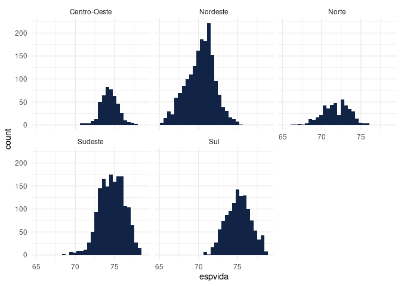

```r
dados_pnud %>%
 filter(ano >= 2010L & ano <= 2010L) %>%
 ggplot() +
  aes(x = espvida) +
  geom_histogram(bins = 30L, fill = "#112446") +
  theme_minimal() +
  facet_wrap(vars(regiao_nm))
```

## Extra - se sobrar tempo!

- Classificar: A função `ifelse()` é uma ótima ferramenta para fazermos classificação com duas categorias. Ex:

```r
dados_pnud %>%
  select(ano, uf_sigla, muni_nm, espvida) |>
  mutate(maior_que_a_media_espvida  =
           ifelse(espvida >= mean(dados_pnud$espvida),
                  "Sim", "Não"))
```

```
## # A tibble: 16,686 × 5
##      ano uf_sigla muni_nm               espvida maior_que_a_media_espvida
##    <dbl> <chr>    <chr>                   <dbl> <chr>
##  1  1991 RO       ALTA FLORESTA D'OESTE    62.0 Não
##  2  1991 RO       ARIQUEMES                66.0 Não
##  3  1991 RO       CABIXI                   63.2 Não
##  4  1991 RO       CACOAL                   65.0 Não
##  5  1991 RO       CEREJEIRAS               62.7 Não
##  6  1991 RO       COLORADO DO OESTE        64.5 Não
##  7  1991 RO       CORUMBIARA               59.3 Não
##  8  1991 RO       COSTA MARQUES            62.8 Não
##  9  1991 RO       ESPIGÃO D'OESTE          64.2 Não
## 10  1991 RO       GUAJARÁ-MIRIM            64.7 Não
## # … with 16,676 more rows
```

- Classificar: a função `case_when()` é interessante para fazer classificação com várias categorias. Ex: classificar a coluna de esperança de vida segundo faixas de idade

```r
# fizemos isso como um exemplo do mutate!
```

- E como podemos usar esses dados classificados?

```r
# fizemos isso como um exemplo do mutate!
```